# relational data

Dylan Lange

October 24, 2017

# Chapter 10

## Group 1 Exercises

### Exercise 1

In order to track this, you will need the variables origin, destination, including the latitude and longitude for the airports. To do this you need to combine weather and airports to the flights table in order to get the origin, dest, and latitude and longitude for each. You could also factor in the weather for the flights if you were interested in some very complex math.

### Exercise 2

The relationship between weather and airports is that origin is faa from the airports table. THis table should show an arrow from faa in airports to origin in weather, then from weather to origin in the flights table.

### Exercise 3

It could also define the relationship to the destination, via the location of the destination and its code. You could also model the reason for the delays, whether that be weather in the origin airport of the destination airport.

### Exercise 4

I would represent it as a holiday data frame. It would include dates and times of these special days from the weather table. I would also include origin and destination from airports as well as the carriers variable from the airlines table.

## Group 2 Exercises

### Exercise 1

```r
mutate(flights, key=row_number())
```

```
## # A tibble: 336,776 x 20
##     year month   day dep_time sched_dep_time dep_delay arr_time
##    <int> <int> <int>    <int>          <int>     <dbl>    <int>
##  1  2013     1     1      517            515         2      830
##  2  2013     1     1      533            529         4      850
##  3  2013     1     1      542            540         2      923
##  4  2013     1     1      544            545        -1     1004
##  5  2013     1     1      554            600        -6      812
##  6  2013     1     1      554            558        -4      740
##  7  2013     1     1      555            600        -5      913
##  8  2013     1     1      557            600        -3      709
##  9  2013     1     1      557            600        -3      838
## 10  2013     1     1      558            600        -2      753
## # ... with 336,766 more rows, and 13 more variables: sched_arr_time <int>,
## #   arr_delay <dbl>, carrier <chr>, flight <int>, tailnum <chr>,
## #   origin <chr>, dest <chr>, air_time <dbl>, distance <dbl>, hour <dbl>,
## #   minute <dbl>, time_hour <dttm>, key <int>
```

### Exercise 2

- a: They key is a combination of PlayerID, YearID, Stint, and TeamID. The player can play in multiple years, multiple stints, within a year, and with multiple teams, so the combination of them is a composite key
- b: There doesn’t seem to be a key within the babynames data, the key would need to be a surrogate key by row number.
- c: year,month seems to be the key for this data because each observation is once per month each year.
- d: id is the key for this table because each vehicle has a separate id.
- e: There is no key in this data set. A surrogate key would have to be added by row number.

### Exercise 3

The Player Id in the batting table links to the player ID in the master table. THe master table holds most of the player information. These tables are also linked by year ID, stint, and team Id. Together, these variables would make a composite key. yearID, teamID, and playerID could also be linked to the salaires table as well.

Manager table is linked ot the Master table through the same composite keys listed above. those being, YearID, TeamID, PlayerID. The same links would be made to the Awards Managers table.

The batting, pitching, and fielding table are linked together by the playerId, yearId, stint, and teamID. The tables then hold the stats that fall within each of the tables.

## Group 3 Exercises

### Exercise 1

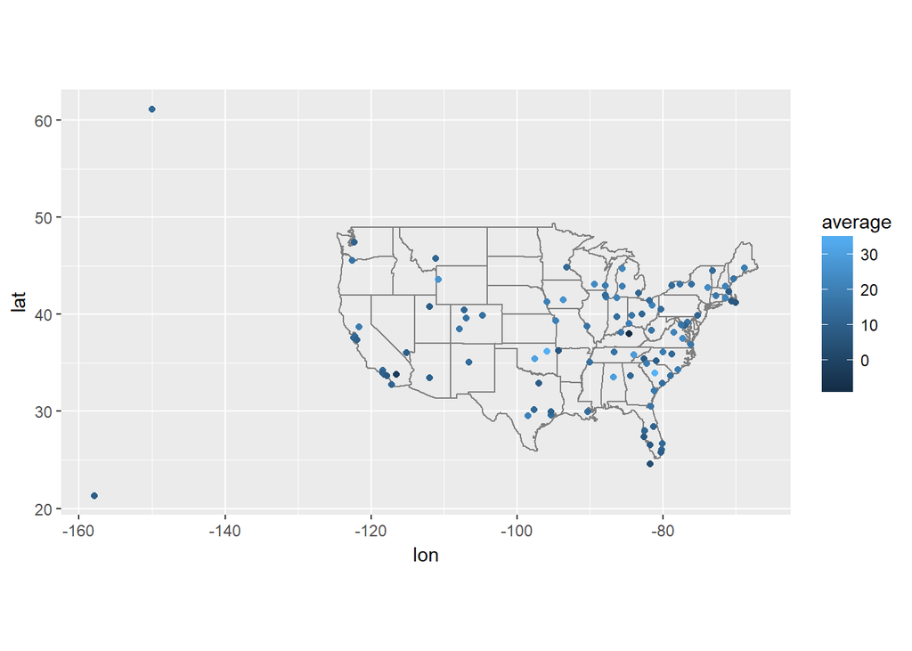

```r
flights2<-flights%>%
  group_by(dest)%>%
  summarise(average=mean(dep_delay,na.rm=TRUE))

airports%>%
  inner_join(flights2, c("faa"="dest"))%>%
  ggplot(aes(lon,lat, color=average))+
    borders("state")+
    geom_point()+
    coord_quickmap()
```

### Exercise 2

```r
flights %>%
  left_join(airports, c("dest"="faa")) %>%
  left_join(airports, c("origin"="faa"))
```

```
## # A tibble: 336,776 x 33
##     year month   day dep_time sched_dep_time dep_delay arr_time
##    <int> <int> <int>    <int>          <int>     <dbl>    <int>
##  1  2013     1     1      517            515         2      830
##  2  2013     1     1      533            529         4      850
##  3  2013     1     1      542            540         2      923
##  4  2013     1     1      544            545        -1     1004
##  5  2013     1     1      554            600        -6      812
##  6  2013     1     1      554            558        -4      740
##  7  2013     1     1      555            600        -5      913
##  8  2013     1     1      557            600        -3      709
##  9  2013     1     1      557            600        -3      838
## 10  2013     1     1      558            600        -2      753
## # ... with 336,766 more rows, and 26 more variables: sched_arr_time <int>,
## #   arr_delay <dbl>, carrier <chr>, flight <int>, tailnum <chr>,
## #   origin <chr>, dest <chr>, air_time <dbl>, distance <dbl>, hour <dbl>,
## #   minute <dbl>, time_hour <dttm>, name.x <chr>, lat.x <dbl>,
## #   lon.x <dbl>, alt.x <int>, tz.x <dbl>, dst.x <chr>, tzone.x <chr>,
## #   name.y <chr>, lat.y <dbl>, lon.y <dbl>, alt.y <int>, tz.y <dbl>,
## #   dst.y <chr>, tzone.y <chr>
```

### Exercise 3

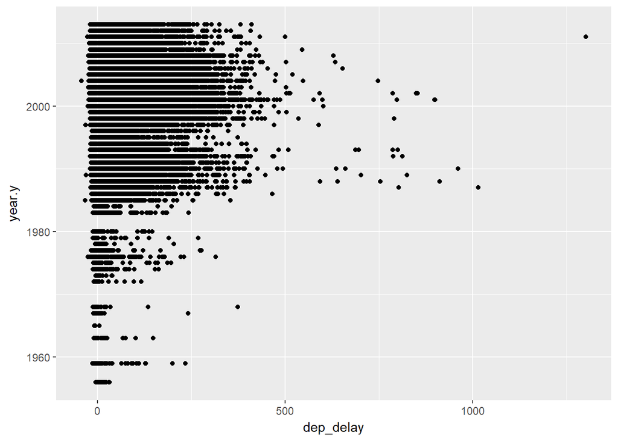

```r
flights%>%
  left_join(planes, by="tailnum")%>%
  select(year.x:day, dep_delay:dep_delay, year.y:year.y, tailnum:tailnum)%>%
  ggplot()+
  geom_point(aes(x=dep_delay, y=year.y))
```

There really isn’t a relationship between age of the plane and delays. While newer planes have more delays, they are also used more often.

### Exercise 4

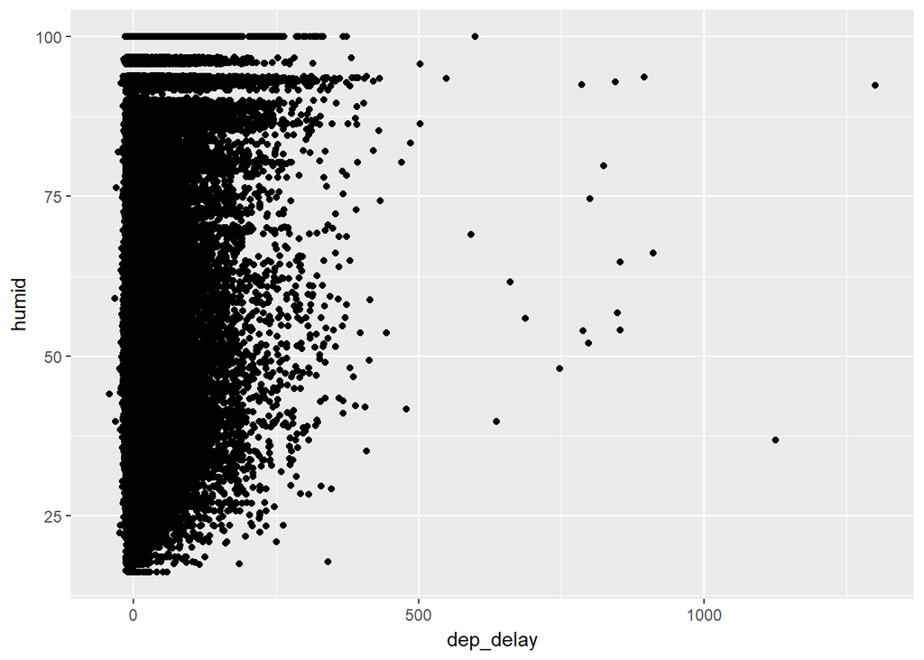

```r
weather%>%
  inner_join(flights)%>%
  select(origin:visib, dep_delay)%>%
  ggplot()+
  geom_point(mapping=aes(x=dep_delay, y=humid))
```

There appears to be small relation between humidity and departure delays. High humidity does not necessarily result in delays, but you are more likely to be delayed if the humidity is higher.

### Exercise 5

```r
flights3<-weather%>%
  right_join(flights, by=c("origin", "year", "month", "day", "hour"))%>%
  filter(month==6, day==13, year==2013) %>%
  group_by(dest)%>%
  summarise(average=mean(dep_delay,na.rm=TRUE))
```

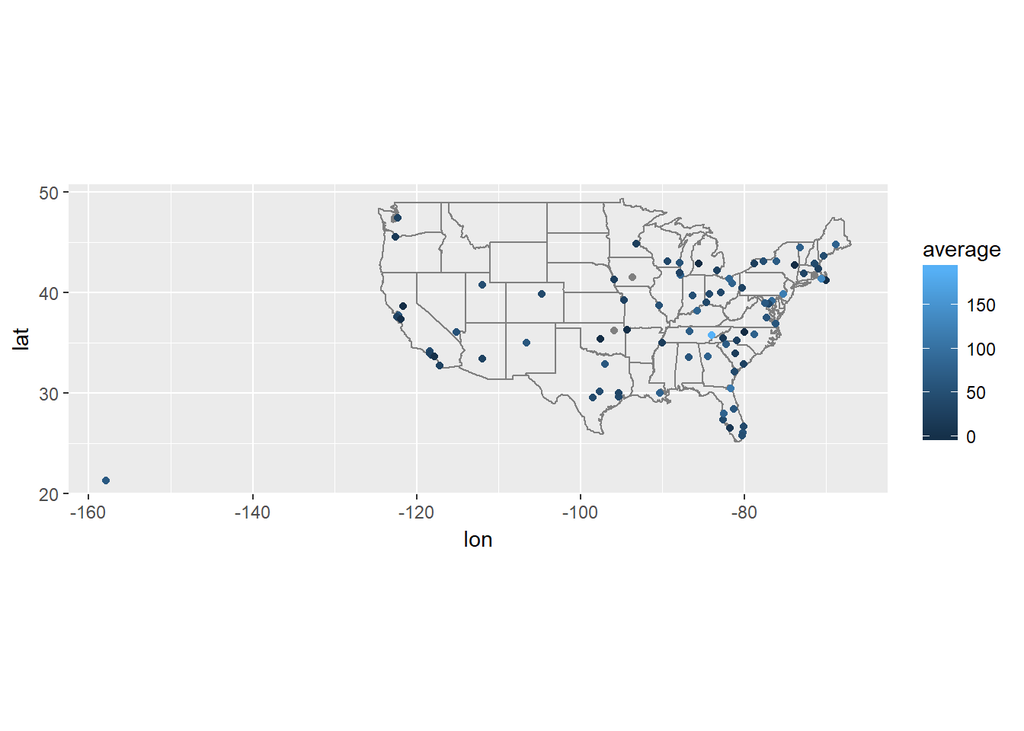

```r
airports%>%
  inner_join(flights3, c("faa"="dest"))%>%
  ggplot(aes(lon,lat, color=average))+
    borders("state")+
    geom_point()+
    coord_quickmap()
```

On June 12 and 13, there were two derecho weather events, which are extremely sever thunderstorms causing delays accross the destinations on the map.

## Group 4 Exercises

### Exercise 1

```r
filter(flights, is.na(tailnum))
```

```
## # A tibble: 2,512 x 19
##     year month   day dep_time sched_dep_time dep_delay arr_time
##    <int> <int> <int>    <int>          <int>     <dbl>    <int>
##  1  2013     1     2       NA           1545        NA       NA
##  2  2013     1     2       NA           1601        NA       NA
##  3  2013     1     3       NA            857        NA       NA
##  4  2013     1     3       NA            645        NA       NA
##  5  2013     1     4       NA            845        NA       NA
##  6  2013     1     4       NA           1830        NA       NA
##  7  2013     1     5       NA            840        NA       NA
##  8  2013     1     7       NA            820        NA       NA
##  9  2013     1     8       NA           1645        NA       NA
## 10  2013     1     9       NA            755        NA       NA
## # ... with 2,502 more rows, and 12 more variables: sched_arr_time <int>,
## #   arr_delay <dbl>, carrier <chr>, flight <int>, tailnum <chr>,
## #   origin <chr>, dest <chr>, air_time <dbl>, distance <dbl>, hour <dbl>,
## #   minute <dbl>, time_hour <dttm>
```

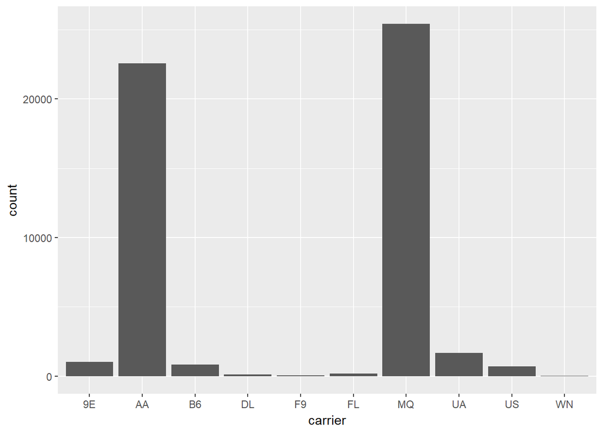

```r
flights%>%
  anti_join(planes, by="tailnum")%>%
  ggplot()+
  geom_bar(mapping=aes(x=carrier))
```

A flight with a missing tailnum is most likely a cancelled flight because they do not have arrival or departure time, nor do they air time.

The flights that don’t have matching tailnums in planes are almost all with the carrier AA or MQ.

### Exercise 2

```r
test<-flights%>%
  anti_join(planes, by="tailnum")%>%
  count(tailnum)%>%
  filter(n>100)

flights%>%
  semi_join(test)
```

```
## # A tibble: 25,450 x 19
##     year month   day dep_time sched_dep_time dep_delay arr_time
##    <int> <int> <int>    <int>          <int>     <dbl>    <int>
##  1  2013     1     1      600            600         0      837
##  2  2013     1     1      602            605        -3      821
##  3  2013     1     1      608            600         8      807
##  4  2013     1     1      624            630        -6      840
##  5  2013     1     1      656            659        -3      949
##  6  2013     1     1      656            705        -9     1007
##  7  2013     1     1      749            710        39      939
##  8  2013     1     1      805            815       -10     1006
##  9  2013     1     1      811            630       101     1047
## 10  2013     1     1      820            820         0     1254
## # ... with 25,440 more rows, and 12 more variables: sched_arr_time <int>,
## #   arr_delay <dbl>, carrier <chr>, flight <int>, tailnum <chr>,
## #   origin <chr>, dest <chr>, air_time <dbl>, distance <dbl>, hour <dbl>,
## #   minute <dbl>, time_hour <dttm>
```

### Exercise 3

```r
filtered<-common%>%
  filter(n>125)
  semi_join(vehicles,filtered)
```

```
## # A tibble: 1,553 x 12
##       id      make  model  year           class           trans
##    <int>     <chr>  <chr> <int>           <chr>           <chr>
##  1  1182 Chevrolet Camaro  1985 Subcompact Cars Automatic 4-spd
##  2  1183 Chevrolet Camaro  1985 Subcompact Cars    Manual 5-spd
##  3  1184 Chevrolet Camaro  1985 Subcompact Cars Automatic 4-spd
##  4    62 Chevrolet Camaro  1985 Subcompact Cars    Manual 5-spd
##  5    63 Chevrolet Camaro  1985 Subcompact Cars Automatic 4-spd
##  6    64 Chevrolet Camaro  1985 Subcompact Cars    Manual 5-spd
##  7    65 Chevrolet Camaro  1985 Subcompact Cars Automatic 4-spd
##  8    66 Chevrolet Camaro  1985 Subcompact Cars    Manual 5-spd
##  9    67 Chevrolet Camaro  1985 Subcompact Cars Automatic 4-spd
## 10  1755 Chevrolet Camaro  1986 Subcompact Cars    Manual 5-spd
## # ... with 1,543 more rows, and 6 more variables: drive <chr>, cyl <int>,
## #   displ <dbl>, fuel <chr>, hwy <int>, cty <int>
```

### Exercise 4

```r
flights %>%
  group_by(month, day, hour) %>%
  summarise(ave_delay = mean(dep_delay, na.rm=TRUE)) %>% ungroup() %>%
  mutate(window_ave_delay = rollapply(ave_delay, 40, mean, align="left", fill=NA_real_)) %>%
  arrange(desc(window_ave_delay))
```

```
## # A tibble: 6,936 x 5
##    month   day  hour ave_delay window_ave_delay
##    <int> <int> <dbl>     <dbl>            <dbl>
##  1     6    26    22 66.875000         54.60608
##  2     6    27    14 41.133333         53.45143
##  3     6    27    15 43.417910         53.32004
##  4     6    27    13 16.720000         53.13277
##  5     6    26    23 58.750000         53.05504
##  6     6    26    20 64.392157         53.01626
##  7     6    27    12 17.769231         53.00601
##  8     6    27    11  7.404255         52.78390
##  9     6    26    21 68.515152         52.76896
## 10     6    27    10 14.489796         52.68219
## # ... with 6,926 more rows
```

```r
filter(weather, month==6 & day>25 & day <29)
```

```
## # A tibble: 216 x 15
##    origin  year month   day  hour  temp  dewp humid wind_dir wind_speed
##     <chr> <dbl> <dbl> <int> <int> <dbl> <dbl> <dbl>    <dbl>      <dbl>
##  1    EWR  2013     6    26     0 82.94 66.92 58.51      240   10.35702
##  2    EWR  2013     6    26     1 82.04 66.02 58.40      240   10.35702
##  3    EWR  2013     6    26     2 80.60 66.20 61.58      240   10.35702
##  4    EWR  2013     6    26     3 75.20 71.60 88.59      260    8.05546
##  5    EWR  2013     6    26     4 77.00 71.06 81.92        0    0.00000
##  6    EWR  2013     6    26     5 75.02 69.98 84.34      210    5.75390
##  7    EWR  2013     6    26     6 75.92 69.98 81.85      260   11.50780
##  8    EWR  2013     6    26     7 73.94 68.00 81.71      270   13.80936
##  9    EWR  2013     6    26     8 73.04 66.02 78.65      260    8.05546
## 10    EWR  2013     6    26     9 73.04 66.02 78.65      240    6.90468
## # ... with 206 more rows, and 5 more variables: wind_gust <dbl>,
## #   precip <dbl>, pressure <dbl>, visib <dbl>, time_hour <dttm>
```

The most apparent difference between the weather in this stretch is that the dew point was significatnly higher that it normally is during that time, however, the precipitation is 0 almost throughout the 48 hours.

### Exercise 5

```r
anti_join(flights, airports, by = c("dest"="faa"))
```

```
## # A tibble: 7,602 x 19
##     year month   day dep_time sched_dep_time dep_delay arr_time
##    <int> <int> <int>    <int>          <int>     <dbl>    <int>
##  1  2013     1     1      544            545        -1     1004
##  2  2013     1     1      615            615         0     1039
##  3  2013     1     1      628            630        -2     1137
##  4  2013     1     1      701            700         1     1123
##  5  2013     1     1      711            715        -4     1151
##  6  2013     1     1      820            820         0     1254
##  7  2013     1     1      820            820         0     1249
##  8  2013     1     1      840            845        -5     1311
##  9  2013     1     1      909            810        59     1331
## 10  2013     1     1      913            918        -5     1346
## # ... with 7,592 more rows, and 12 more variables: sched_arr_time <int>,
## #   arr_delay <dbl>, carrier <chr>, flight <int>, tailnum <chr>,
## #   origin <chr>, dest <chr>, air_time <dbl>, distance <dbl>, hour <dbl>,
## #   minute <dbl>, time_hour <dttm>
```

This is all the flights where the destination is not included in the airports table.

```r
anti_join(airports, flights, by = c("faa" = "dest"))
```

```
## # A tibble: 1,357 x 8
##      faa                           name      lat        lon   alt    tz
##    <chr>                          <chr>    <dbl>      <dbl> <int> <dbl>
##  1   04G              Lansdowne Airport 41.13047  -80.61958  1044    -5
##  2   06A  Moton Field Municipal Airport 32.46057  -85.68003   264    -6
##  3   06C            Schaumburg Regional 41.98934  -88.10124   801    -6
##  4   06N                Randall Airport 41.43191  -74.39156   523    -5
##  5   09J          Jekyll Island Airport 31.07447  -81.42778    11    -5
##  6   0A9 Elizabethton Municipal Airport 36.37122  -82.17342  1593    -5
##  7   0G6        Williams County Airport 41.46731  -84.50678   730    -5
##  8   0G7  Finger Lakes Regional Airport 42.88356  -76.78123   492    -5
##  9   0P2   Shoestring Aviation Airfield 39.79482  -76.64719  1000    -5
## 10   0S9          Jefferson County Intl 48.05381 -122.81064   108    -8
## # ... with 1,347 more rows, and 2 more variables: dst <chr>, tzone <chr>
```

This shows all the airports that don’t have a matching destination in flights.

### Exercise 6

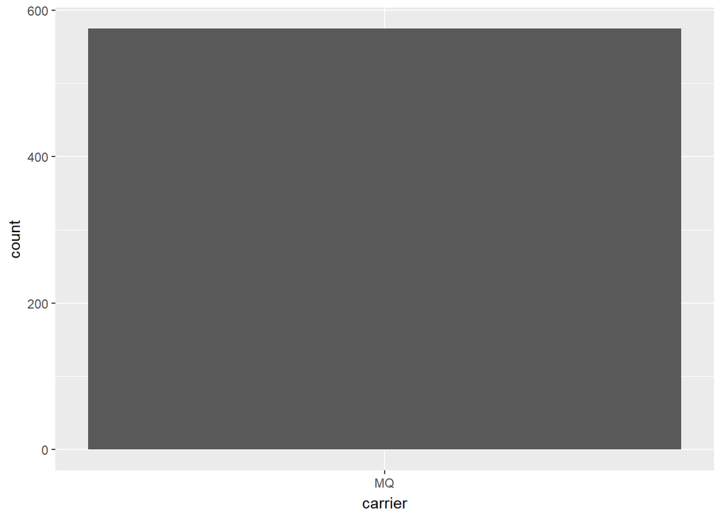

```r
top_ten<-flights%>%
  count(tailnum, sort=TRUE)%>%
  head(10)
semi_join(flights, top_ten)%>%
  filter(tailnum=="N725MQ")%>%
  ggplot()+
  geom_bar(mapping=aes(x=carrier))
```

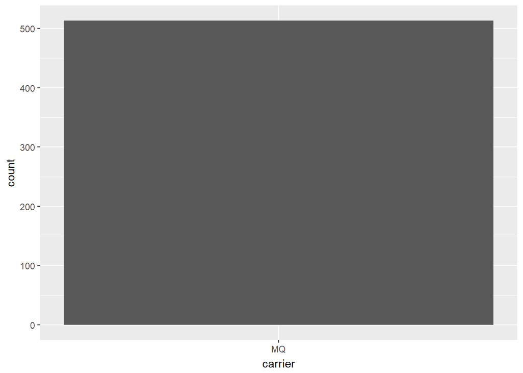

```r
semi_join(flights, top_ten)%>%
  filter(tailnum=="N722MQ")%>%
  ggplot()+
  geom_bar(mapping=aes(x=carrier))
```

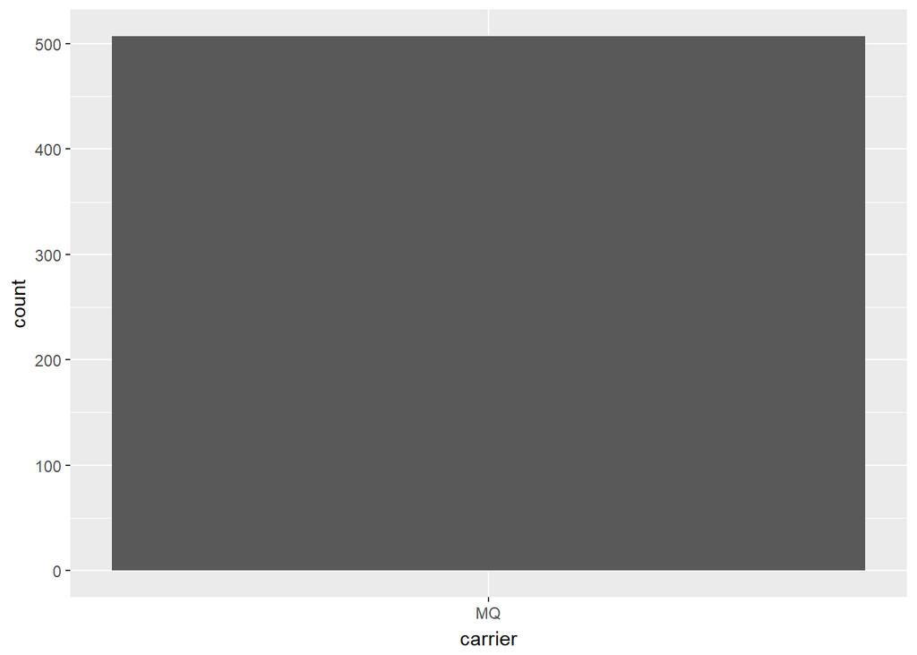

```r
semi_join(flights, top_ten)%>%
  filter(tailnum=="N723MQ")%>%
  ggplot()+
  geom_bar(mapping=aes(x=carrier))
```

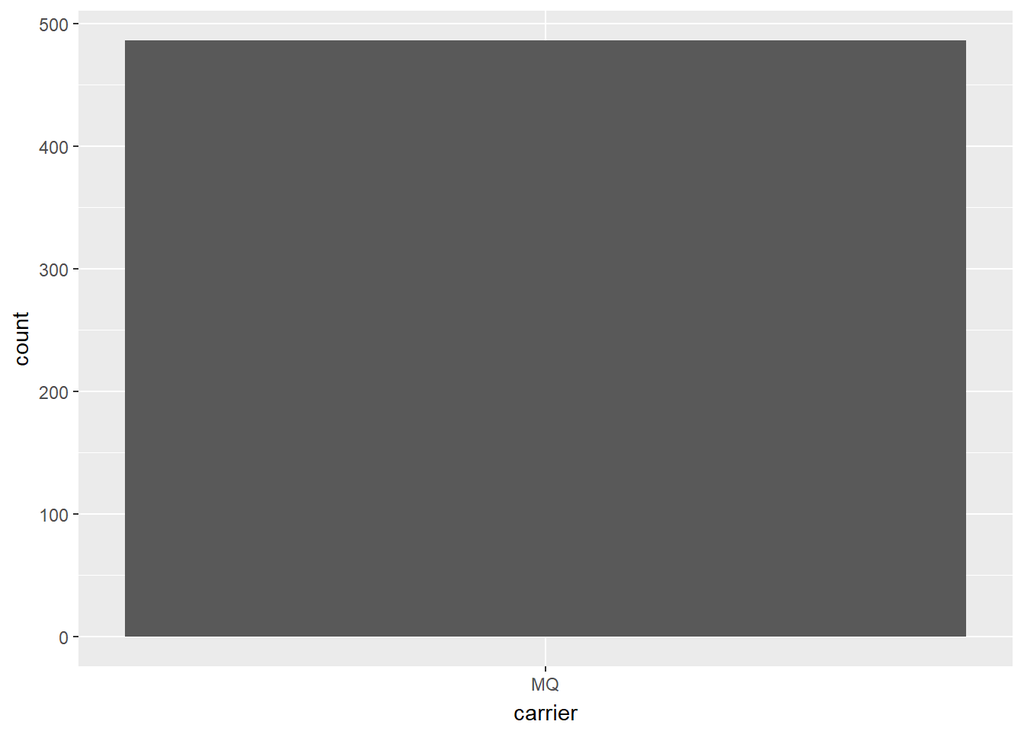

```r
semi_join(flights, top_ten)%>%
  filter(tailnum=="N711MQ")%>%
  ggplot()+
  geom_bar(mapping=aes(x=carrier))
```

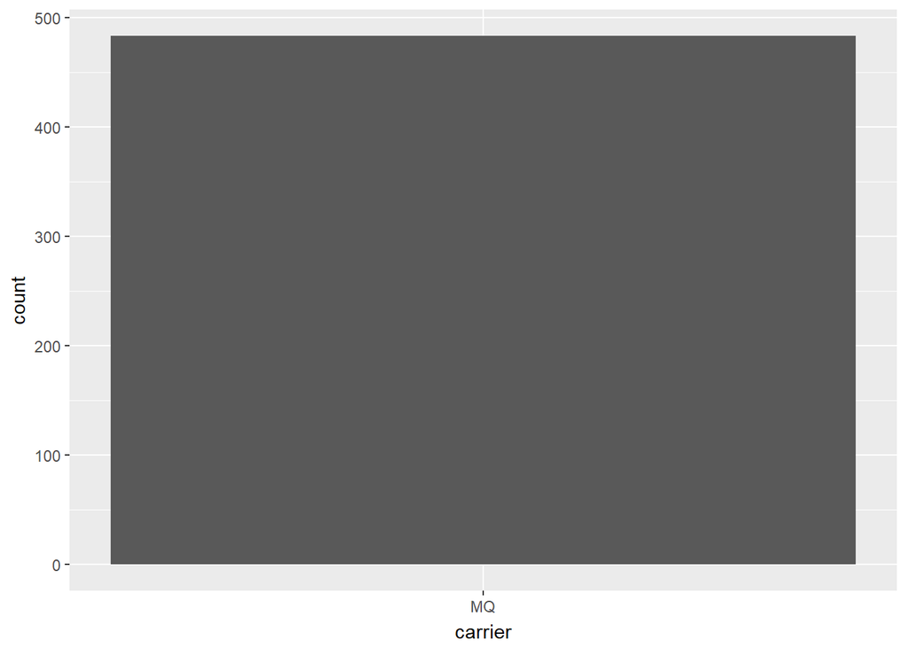

```r
semi_join(flights, top_ten)%>%
  filter(tailnum=="N713MQ")%>%
  ggplot()+
  geom_bar(mapping=aes(x=carrier))
```

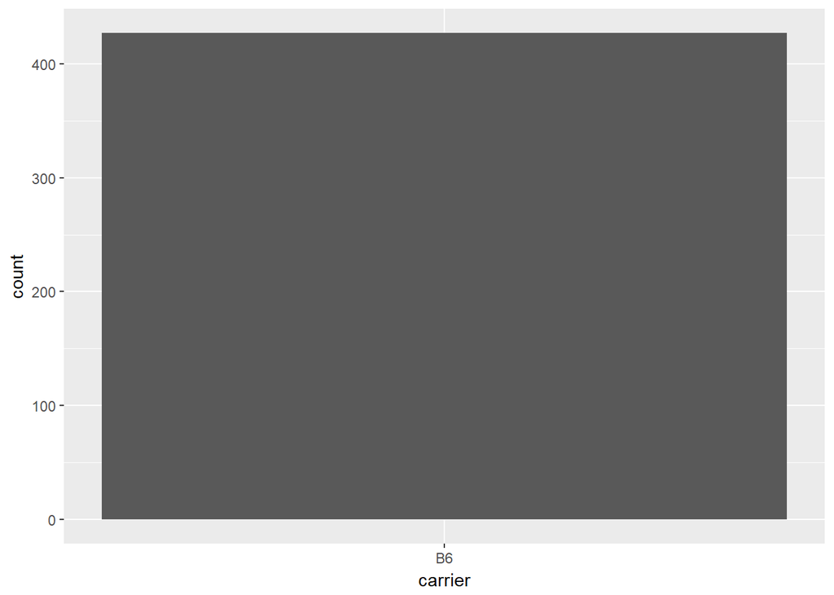

```r
semi_join(flights, top_ten)%>%
  filter(tailnum=="N258JB")%>%
  ggplot()+
  geom_bar(mapping=aes(x=carrier))
```

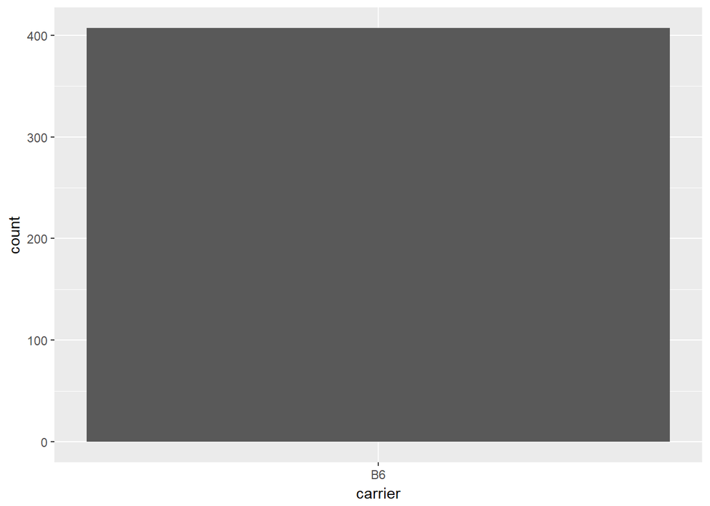

```r
semi_join(flights, top_ten)%>%
  filter(tailnum=="N298JB")%>%
  ggplot()+
  geom_bar(mapping=aes(x=carrier))
```

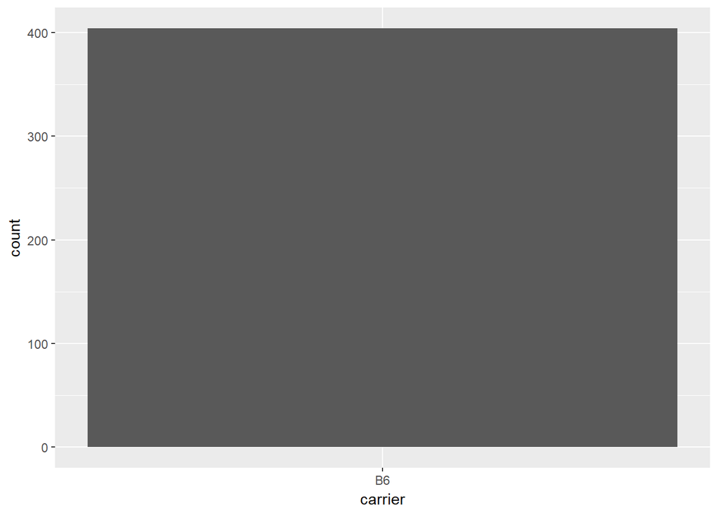

```r
semi_join(flights, top_ten)%>%
  filter(tailnum=="N353JB")%>%
  ggplot()+
  geom_bar(mapping=aes(x=carrier))
```

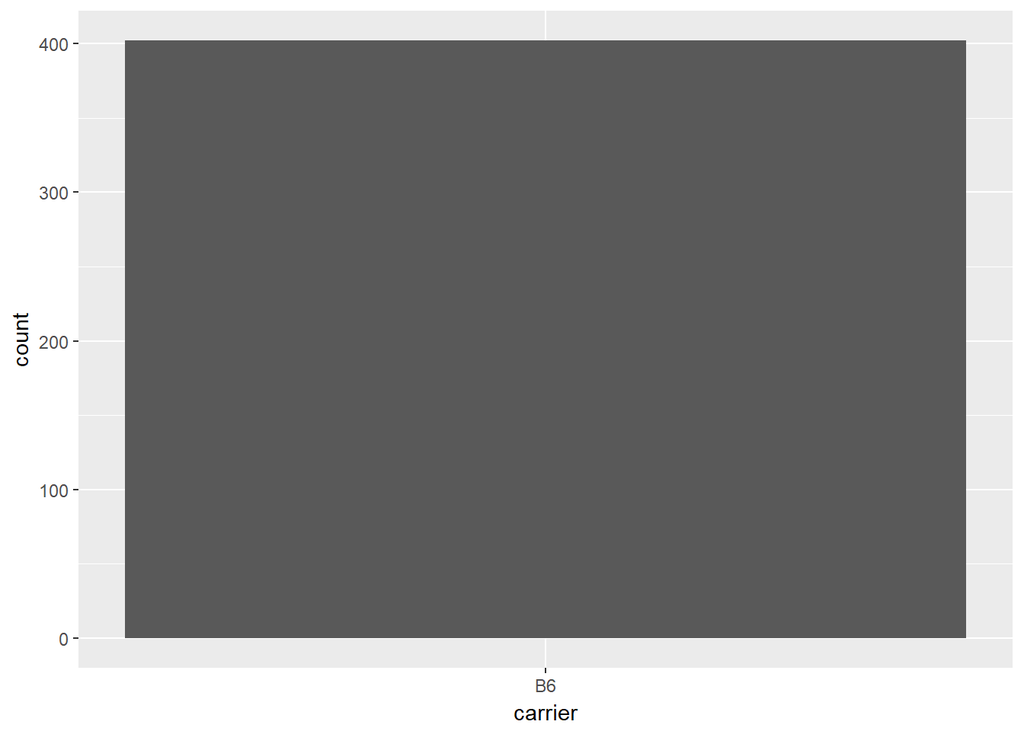

```r
semi_join(flights, top_ten)%>%
  filter(tailnum=="N351JB")%>%
  ggplot()+
  geom_bar(mapping=aes(x=carrier))
```

For the top 9 most common tail numbers, they each have only one carrier listed in the flight table. They carrier and tailnumber are related.